# Machine Learning techniques for Anomaly Detection

# Agenda

### 1. Data exploration

### 2. Univariate anomaly detection

```
    2.1. Descriptive stastistics
    2.2. Visualization
    2.3. Z-score
    2.4. Smoothed z-score
```

### 3. Multivariate anomaly detection

```
    3.1. K-means
    3.2. DBSCAN
    3.3. Isolation Forest
    3.4. Elliptic Envelope
    3.5. One-Class SVM
    3.6. Autoencoder
```

* Disclaimer: Dataset used for this tutorial is a public dataset, withdrown from UCI Machine Learning Repository. Having that in mind, all limitations and intepretations regarding the usage should be carefully taken into account.

** Disclaimer: Examples provided are used only as introductory materials. The main idea is to get familiar with algorithms, while the usage and accuracy of interpretations highly depend on the concrete problem being defined and level of familiarity with the domain being explored.

```python
# import dependencies
import pandas as pd
import numpy as np
import matplotlib.pyplot as plt
from pandas.plotting import register_matplotlib_converters
register_matplotlib_converters()
```

```python
raw_df = pd.read_excel('data/Online Retail.xlsx')
```

```python
raw_df.head()
```

|  | InvoiceNo | StockCode | Description | Quantity | InvoiceDate | UnitPrice | CustomerID | Country |
| --- | --- | --- | --- | --- | --- | --- | --- | --- |
| 0 | 536365 | 85123A | WHITE HANGING HEART T-LIGHT HOLDER | 6 | 2010-12-01 08:26:00 | 2.55 | 17850.0 | United Kingdom |
| 1 | 536365 | 71053 | WHITE METAL LANTERN | 6 | 2010-12-01 08:26:00 | 3.39 | 17850.0 | United Kingdom |
| 2 | 536365 | 84406B | CREAM CUPID HEARTS COAT HANGER | 8 | 2010-12-01 08:26:00 | 2.75 | 17850.0 | United Kingdom |
| 3 | 536365 | 84029G | KNITTED UNION FLAG HOT WATER BOTTLE | 6 | 2010-12-01 08:26:00 | 3.39 | 17850.0 | United Kingdom |
| 4 | 536365 | 84029E | RED WOOLLY HOTTIE WHITE HEART. | 6 | 2010-12-01 08:26:00 | 3.39 | 17850.0 | United Kingdom |

```python
raw_df['Date'] = raw_df['InvoiceDate'].dt.date
```

```python
raw_df.head()
```

|  | InvoiceNo | StockCode | Description | Quantity | InvoiceDate | UnitPrice | CustomerID | Country | Date |
| --- | --- | --- | --- | --- | --- | --- | --- | --- | --- |
| 0 | 536365 | 85123A | WHITE HANGING HEART T-LIGHT HOLDER | 6 | 2010-12-01 08:26:00 | 2.55 | 17850.0 | United Kingdom | 2010-12-01 |
| 1 | 536365 | 71053 | WHITE METAL LANTERN | 6 | 2010-12-01 08:26:00 | 3.39 | 17850.0 | United Kingdom | 2010-12-01 |
| 2 | 536365 | 84406B | CREAM CUPID HEARTS COAT HANGER | 8 | 2010-12-01 08:26:00 | 2.75 | 17850.0 | United Kingdom | 2010-12-01 |
| 3 | 536365 | 84029G | KNITTED UNION FLAG HOT WATER BOTTLE | 6 | 2010-12-01 08:26:00 | 3.39 | 17850.0 | United Kingdom | 2010-12-01 |
| 4 | 536365 | 84029E | RED WOOLLY HOTTIE WHITE HEART. | 6 | 2010-12-01 08:26:00 | 3.39 | 17850.0 | United Kingdom | 2010-12-01 |

```python
raw_df['Total_value_paid'] = raw_df['Quantity']*raw_df['UnitPrice']
```

- Create sales analytics and customer analytics datasets that can be used for exploration

```python
sale_analytics = raw_df.groupby('Date', as_index=False).agg({
    'Total_value_paid':'sum',
    'CustomerID':'nunique',
    'StockCode':'count'
})
```

```python
sale_analytics.head()
```

|  | Date | Total_value_paid | CustomerID | StockCode |
| --- | --- | --- | --- | --- |
| 0 | 2010-12-01 | 58635.56 | 98 | 3108 |
| 1 | 2010-12-02 | 46207.28 | 117 | 2109 |
| 2 | 2010-12-03 | 45620.46 | 55 | 2202 |
| 3 | 2010-12-05 | 31383.95 | 76 | 2725 |
| 4 | 2010-12-06 | 53860.18 | 90 | 3878 |

```python
sale_analytics.rename(columns={'Total_value_paid':'Revenue',
                               'CustomerID':'Number_of_customers',
                               'StockCode':'Number_of_products'},
                      inplace=True)
```

- Customers dataset

```python
customer_analytics = raw_df.groupby('CustomerID', as_index=False).agg({
    'Total_value_paid':'sum',
    'InvoiceNo':'nunique',
    'StockCode':'count'
})
```

```python
customer_analytics.rename(columns={'Total_value_paid':'Revenue',
                               'InvoiceNo':'Number_of_purchases',
                               'StockCode':'Number_of_products'},
                      inplace=True)
```

- Analytics

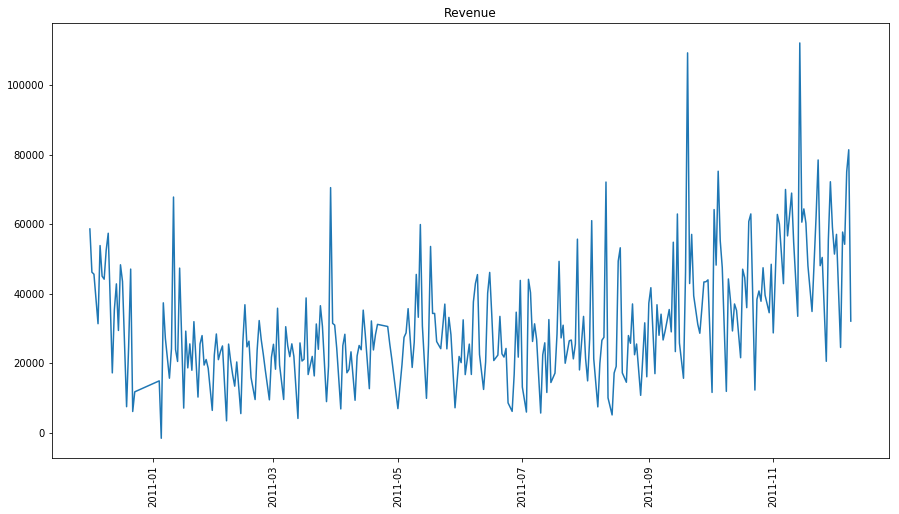

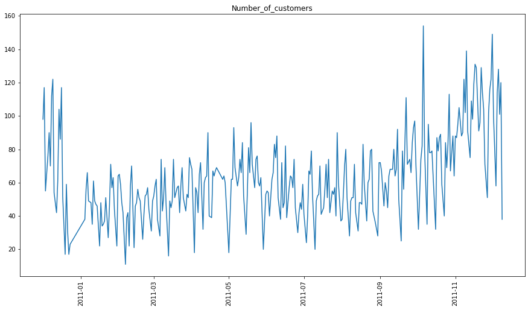

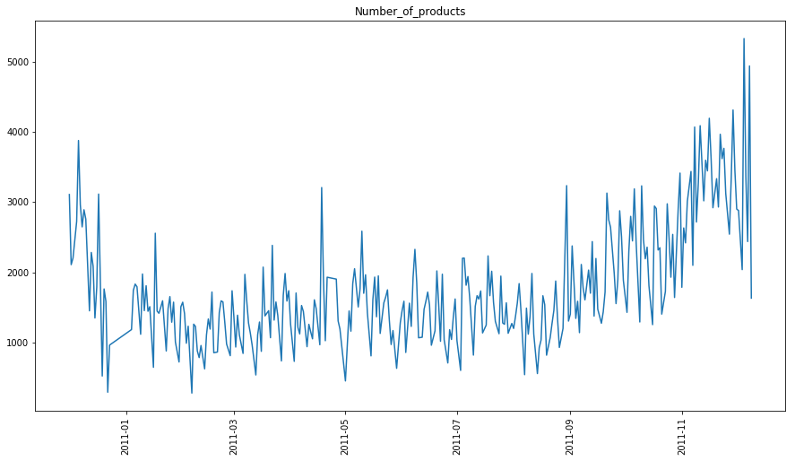

```python
# plot sales analytics by every feature
for column in sale_analytics.columns[1:]:
    plt.figure(figsize=(15, 8));
    plt.plot(sale_analytics['Date'], sale_analytics[column]);
    plt.title(column);
    plt.xticks(rotation=90);
```

- Descriptive analysis of outliers- dataframe.describe()

Descriptive statitics can be used to quantitatively analyze the data. Analyzing quantiles can be insightful for getting rough estimation on the data distribution and the existance of outliers. It can be noticed that there are negative values, as well as extreemly high values for Revenue. Negative values may apply that some items have been returned, or that some mistake was made, and those records (as well as corresponding records if needed) should be safely removed from the dataset, after talking to the domain expert and confirming the possible root causes.

For now, let's leave these records, since we want to test if the algorithms will be able to identify deviant behaviour, which is our main task here.

```python
sale_analytics.describe()
```

|  | Revenue | Number_of_customers | Number_of_products |
| --- | --- | --- | --- |
| count | 305.000000 | 305.000000 | 305.000000 |
| mean | 31959.829292 | 63.265574 | 1776.750820 |
| std | 17414.261664 | 25.363767 | 829.894514 |
| min | -1566.230000 | 11.000000 | 279.000000 |
| 25% | 20728.140000 | 47.000000 | 1229.000000 |
| 50% | 27978.410000 | 60.000000 | 1577.000000 |
| 75% | 42912.400000 | 75.000000 | 2109.000000 |
| max | 112141.110000 | 154.000000 | 5331.000000 |

- Visual analysis of outliers - pyplot.boxplot()

Visual analysis may be a pretty easy and elegant way to identify outliers. Boxplot is one of the most commonly used tools for graphically representing the distribution of the data, simultaneously analysing the quartiles and the median value. It can be seen that there are some days when there were lots of customers, more than 120, while in most cases this number ranges from 45-75 customers on a daily level.

For further information regarding the interpretation, please follow this link: https://towardsdatascience.com/understanding-boxplots-5e2df7bcbd51.

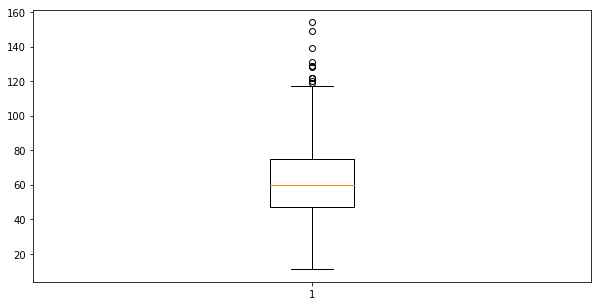

```python
plt.figure(figsize=(10, 5));
plt.boxplot(sale_analytics['Number_of_customers']);
```

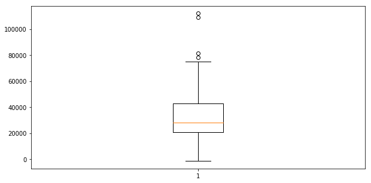

```python
plt.figure(figsize=(10, 5));
plt.boxplot(sale_analytics['Revenue']);
# plt.yticks(np.arange(sale_analytics['Revenue'].min(), 150000, 10000));
```

- Analyze seasonality

When working with the time series, the seasonality in the data may be tricky and misleading. Besides, we need to make sure that we caught the right time frame describing all seasons and periods. When dealing with the anomalies in the data, we should keep in mind that having extreeme values that occur on a periodical level should not be treated as anomalies, since they repeat and are a characteristic of the behaviour being modeled.

One of the first thing to analyze when dealing with sales over the time is the difference between weekends and other days. It often happens that sales jumps for the weekend, or on a specific day of week. The following graph shows the distribution of sales during the weekend and other days on the week. It can be noticed that the sales is dropping on weekends (which does make sense, since it is and online retail shop), and that the data is skewed, and that there are some bins with few instance and extreeme values, which points to the existance of outliers in the data.

```python
sale_analytics['Weekday'] = pd.to_datetime(sale_analytics['Date']).dt.weekday
```

```python
sale_analytics.head()
```

|  | Date | Revenue | Number_of_customers | Number_of_products | Weekday |
| --- | --- | --- | --- | --- | --- |
| 0 | 2010-12-01 | 58635.56 | 98 | 3108 | 2 |
| 1 | 2010-12-02 | 46207.28 | 117 | 2109 | 3 |
| 2 | 2010-12-03 | 45620.46 | 55 | 2202 | 4 |
| 3 | 2010-12-05 | 31383.95 | 76 | 2725 | 6 |
| 4 | 2010-12-06 | 53860.18 | 90 | 3878 | 0 |

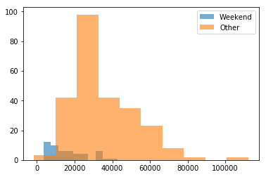

```python
plt.hist(sale_analytics[sale_analytics['Weekday'].isin([5,6])]['Revenue'], alpha=0.6, label='Weekend');
plt.hist(sale_analytics[~(sale_analytics['Weekday'].isin([5,6]))]['Revenue'], alpha=0.6, label='Other');
plt.legend();
```

- Revenue distribution per weekday

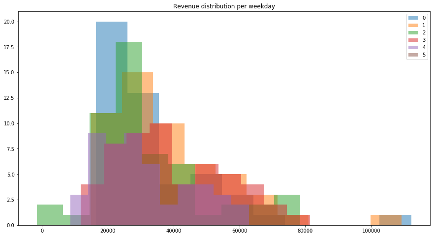

```python
plt.figure(figsize=(15, 8));
for day in range(0,6):
    plt.hist(sale_analytics[sale_analytics['Weekday']==day]['Revenue'], alpha=0.5, label=day);
plt.legend();
plt.title('Revenue distribution per weekday');
```

# Univariate anomaly detection

- Z-score

Z-score is something that I have stumbled upon when first started working with outliers.

It basically tells how many standard deviations a particular point value is from the mean value. The formula is pretty simple:

\begin{align} Z(x) & = \frac{x-\mu}{\sigma} \\ \end{align}

Since I've had some second thoughts about using it for non normally distributed data, I will share the following link with you, it may come in handy: https://www.quora.com/Can-a-z-score-be-used-for-non-normal-distributions-If-not-then-how-do-you-approach-similar-probability-questions.

**Pros**: extremely fast and efficient way to detect high deviations.

**Cons**: not efficient when dealing with the time series data having noticeable trend, or lots of trend changepoints.

```python
def outliers_z_score(ys, threshold):
    mean_y = np.mean(ys)
    stdev_y = np.std(ys)
    z_scores = [(y - mean_y) / stdev_y for y in ys]
    return np.where(np.abs(z_scores) > threshold)
```

```python
outliers = outliers_z_score(sale_analytics['Number_of_customers'], 2.5)[0]
```

```python
outliers
```

```
array([249, 279, 285, 286, 289, 297, 301])
```

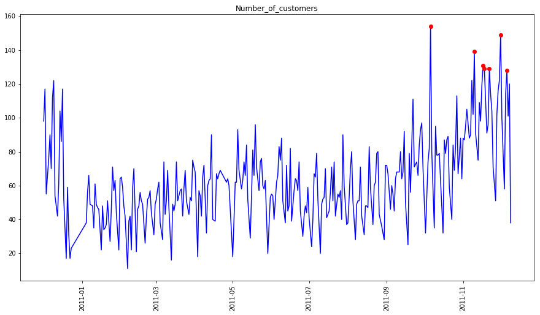

```python
plt.figure(figsize=(15, 8));
plt.plot(sale_analytics['Date'], sale_analytics['Number_of_customers'], 'b');
plt.plot(sale_analytics.loc[outliers]['Date'], sale_analytics.loc[outliers]['Number_of_customers'], 'or');
plt.title('Number_of_customers');
plt.xticks(rotation=90);
```

```python
outliers=[]
for column in ['Revenue', 'Number_of_customers', 'Number_of_products']:
    outlier_indexes = list(outliers_z_score(sale_analytics[column],2.5)[0])
    outliers = outliers+outlier_indexes
```

```python
outliers_df = sale_analytics.loc[outliers]
```

```python
sale_analytics.loc[outliers]
```

|  | Date | Revenue | Number_of_customers | Number_of_products | Weekday |
| --- | --- | --- | --- | --- | --- |
| 235 | 2011-09-20 | 109286.21 | 56 | 1718 | 1 |
| 282 | 2011-11-14 | 112141.11 | 109 | 3597 | 0 |
| 290 | 2011-11-23 | 78480.70 | 114 | 3619 | 2 |
| 303 | 2011-12-08 | 81417.78 | 120 | 4940 | 3 |
| 249 | 2011-10-06 | 55306.28 | 154 | 3189 | 3 |
| 279 | 2011-11-10 | 68956.24 | 139 | 3275 | 3 |
| 285 | 2011-11-17 | 60329.72 | 131 | 3621 | 3 |
| 286 | 2011-11-18 | 48031.80 | 129 | 2920 | 4 |
| 289 | 2011-11-22 | 62307.32 | 129 | 3967 | 1 |
| 297 | 2011-12-01 | 51410.95 | 149 | 2901 | 3 |
| 301 | 2011-12-06 | 54228.37 | 128 | 3365 | 1 |
| 4 | 2010-12-06 | 53860.18 | 90 | 3878 | 0 |
| 277 | 2011-11-08 | 56647.66 | 122 | 4070 | 1 |
| 280 | 2011-11-11 | 54835.51 | 91 | 4089 | 4 |
| 284 | 2011-11-16 | 64408.70 | 119 | 4195 | 2 |
| 289 | 2011-11-22 | 62307.32 | 129 | 3967 | 1 |
| 295 | 2011-11-29 | 72219.20 | 116 | 4313 | 1 |
| 300 | 2011-12-05 | 57751.32 | 114 | 5331 | 0 |
| 303 | 2011-12-08 | 81417.78 | 120 | 4940 | 3 |

```python
sale_analytics['Anomaly_ZC'] = 0
```

```python
sale_analytics['Anomaly_ZC'].loc[outliers] = 1
```

- Smoothed z-score

Smoothed Z-score is a Z-score upgraded with a mechanism for taking only last N values into account.

It is pretty convenient for time series data with trends and lots of trend changepoints.

Besides, you can easily manipulate with the influence and lag parameters, which provide the possibility to "smooth" up the data based on the most recent behaviour, and identify high deviations regarding the most recent time frame.

The following function has been taken from this GitHub account: https://gist.github.com/ximeg. A more detailed explanation has been taken from StackOverflow linked within:

#### Rules of thumb for configuring the algorithm

**lag**: the lag parameter determines how much your data will be smoothed and how adaptive the algorithm is to changes in the long-term average of the data. The more stationary your data is, the more lags you should include (this should improve the robustness of the algorithm). If your data contains time-varying trends, you should consider how quickly you want the algorithm to adapt to these trends. I.e., if you put lag at 10, it takes 10 'periods' before the algorithm's treshold is adjusted to any systematic changes in the long-term average. So choose the lag parameter based on the trending behavior of your data and how adaptive you want the algorithm to be.

**influence**: this parameter determines the influence of signals on the algorithm's detection threshold. If put at 0, signals have no influence on the threshold, such that future signals are detected based on a threshold that is calculated with a mean and standard deviation that is not influenced by past signals. Another way to think about this is that if you put the influence at 0, you implicitly assume stationarity (i.e. no matter how many signals there are, the time series always returns to the same average over the long term). If this is not the case, you should put the influence parameter somewhere between 0 and 1, depending on the extent to which signals can systematically influence the time-varying trend of the data. E.g., if signals lead to a structural break of the long-term average of the time series, the influence parameter should be put high (close to 1) so the threshold can adjust to these changes quickly.

**threshold**: the threshold parameter is the number of standard deviations from the moving mean above which the algorithm will classify a new datapoint as being a signal. For example, if a new datapoint is 4.0 standard deviations above the moving mean and the threshold parameter is set as 3.5, the algorithm will identify the datapoint as a signal. This parameter should be set based on how many signals you expect. For example, if your data is normally distributed, a threshold (or: z-score) of 3.5 corresponds to a signaling probability of 0.00047 (from this table), which implies that you expect a signal once every 2128 datapoints (1/0.00047). The threshold therefore directly influences how sensitive the algorithm is and thereby also how often the algorithm signals. Examine your own data and determine a sensible threshold that makes the algorithm signal when you want it to (some trial-and-error might be needed here to get to a good threshold for your purpose).

P.S. I've been bold enough to adjust the code a little bit, so it can be more intuitive.

**Pros**: Extreemly fast and efficient; convenient when working with time series data with noticeable trend and lots of trend changepoints, when giving more importance to the recent behaviour.

**Cons**: Cannot be used for multivariate analysis, when there is a need to extract and analyse interdependence between variables

```python
def smoothed_z_score(input_values, lag, threshold, influence):
    signals = np.zeros(len(input_values))
    smoothed_values = np.array(input_values)
    mean_values = [0]*len(input_values)
    std_values = [0]*len(input_values)
    mean_values[lag - 1] = np.mean(input_values[0:lag])
    std_values[lag - 1] = np.std(input_values[0:lag])
    for i in range(lag, len(input_values) - 1):
        if abs(input_values[i] - mean_values[i-1]) > threshold * std_values [i-1]:
            if input_values[i] > mean_values[i-1]:
                signals[i] = 1
            else:
                signals[i] = -1

            smoothed_values[i] = influence * input_values[i] + (1 - influence) * smoothed_values[i-1]
            mean_values[i] = np.mean(smoothed_values[(i-lag):i])
            std_values[i] = np.std(smoothed_values[(i-lag):i])
        else:
            signals[i] = 0
            smoothed_values[i] = input_values[i]
            mean_values[i] = np.mean(smoothed_values[(i-lag):i])
            std_values[i] = np.std(smoothed_values[(i-lag):i])

    return pd.DataFrame(dict(signals = np.asarray(signals),
                            mean_values = np.asarray(mean_values),
                            std_values = np.asarray(std_values)))
```

```python
lag = 7
threshold = 3
influence = 0.8

# Run algo with settings from above
result = smoothed_z_score(sale_analytics['Number_of_customers'], lag=lag, threshold=threshold, influence=influence)
```

```python
result = sale_analytics.merge(result, left_index=True, right_index=True)
```

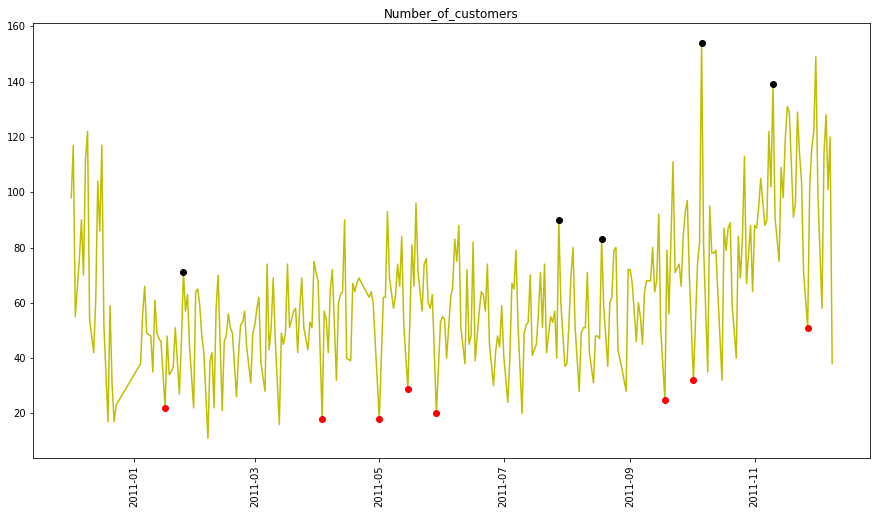

```python
plt.figure(figsize=(15, 8));
plt.plot(result['Date'], result['Number_of_customers'], 'y');
plt.plot(result[result['signals']==-1]['Date'], sale_analytics[result['signals']==-1]['Number_of_customers'], 'or');
plt.plot(result[result['signals']==1]['Date'], sale_analytics[result['signals']==1]['Number_of_customers'], 'ok');
plt.title('Number_of_customers');
plt.xticks(rotation=90);
```

### Explore further

- Time series anomaly detection with Moving Average and Prophet: https://towardsdatascience.com/anomaly-detection-def662294a4e
- Time series anomaly detection with SARIMA model combination: https://towardsdatascience.com/anomaly-detection-with-time-series-forecasting-c34c6d04b24a
- For R lovers:
  - https://anomaly.io/detect-anomalies-in-correlated-time-series/index.html
  - https://anomaly.io/anomaly-detection-moving-median-decomposition/index.html
- Benchmark with various algorithms for time series anomaly detection: https://github.com/animeshgoyal9/Detecting-Onset-of-Machine-Failure-using-Anomaly-Detection/blob/master/Anomaly%20Detection%20in%20Time%20Series.ipynb

# Multivariate anomaly detection

## Clustering based anomaly detection

**K-Means**

K-means as a distance-based clustering algorithm is pretty sensitive to the existance of outliers. However, this algorithm, on the contrary, is often used particularly for outlier detection. The general idea is that outlier distances are those that are the furthest from the nearest cluster centroid.

Specifically due to its nature, K-means can be used for identifying a cluster of a collective anomaly. Further more, it can be convenient for the problem of masking, when a collective anomaly is regarded as a normal behaviour, because of the density or the number of instances within.

**Pros**: Efficient and fast, working with multiple variables.

**Cons**: Distance-based, not convenient for categorical variables.

```python
from sklearn.cluster import KMeans
```

```python
customer_analytics.head()
```

|  | CustomerID | Revenue | Number_of_purchases | Number_of_products |
| --- | --- | --- | --- | --- |
| 0 | 12346.0 | 0.00 | 2 | 2 |
| 1 | 12347.0 | 4310.00 | 7 | 182 |
| 2 | 12348.0 | 1797.24 | 4 | 31 |
| 3 | 12349.0 | 1757.55 | 1 | 73 |
| 4 | 12350.0 | 334.40 | 1 | 17 |

```python
from sklearn.preprocessing import MinMaxScaler
```

```python
features_to_use = ['Revenue', 'Number_of_purchases', 'Number_of_products']
customer_analytics_subset = customer_analytics[features_to_use]
```

```python
normalized_data = MinMaxScaler(feature_range=(0,1)).fit_transform(customer_analytics_subset)
data = pd.DataFrame(normalized_data, columns=features_to_use)
```

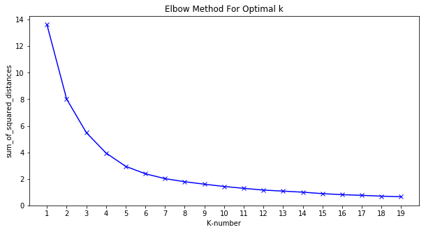

```python
n_cluster = range(1, 20)
sum_of_squared_distances = []
for k in n_cluster:
    model = KMeans(n_clusters=k)
    model = model.fit(data)
    sum_of_squared_distances.append(model.inertia_)

plt.figure(figsize=(10, 5));
plt.plot(n_cluster, sum_of_squared_distances, 'bx-')
plt.xlabel('K-number')
plt.ylabel('sum_of_squared_distances')
plt.xticks(n_cluster)
plt.title('Elbow Method For Optimal k');
```

```python
from mpl_toolkits.mplot3d import Axes3D
```

```python
model = KMeans(n_clusters=6).fit(data)
```

```python
def getDistanceByPoint(data, model):
    distance = pd.Series()
    for i in range(0,len(data)):
        Xa = np.array(data.loc[i])
        Xb = model.cluster_centers_[model.labels_[i]-1]
        distance.set_value(i, np.linalg.norm(Xa-Xb))
    return distance

outliers_fraction = 0.1
# get the distance between each point and its nearest centroid. The biggest distances are considered as anomalies
distance = getDistanceByPoint(data, model)
number_of_outliers = int(outliers_fraction*len(distance))
threshold = distance.nlargest(number_of_outliers).min()
# anomaly1 contain the anomaly result of the above method Cluster (0:normal, 1:anomaly)
customer_analytics['anomaly_kmeans'] = (distance >= threshold).astype(int)
customer_analytics['anomaly_kmeans'] = customer_analytics['anomaly_kmeans'].map({1:-1})
```

```python
#Plotting
def plot_normal_vs_anomalous(customer_analytics, anomaly_flag, title):
    fig = plt.figure(1, figsize=(10,10))
    ax = Axes3D(fig, rect=[0, 0, 0.95, 1], elev=48, azim=210)
    ax.scatter(customer_analytics[customer_analytics[anomaly_flag]!=-1][features_to_use[0]],
               customer_analytics[customer_analytics[anomaly_flag]!=-1][features_to_use[1]],
               customer_analytics[customer_analytics[anomaly_flag]!=-1][features_to_use[2]],
               c='blue')
    ax.scatter(customer_analytics[customer_analytics[anomaly_flag]==-1][features_to_use[0]],
               customer_analytics[customer_analytics[anomaly_flag]==-1][features_to_use[1]],
               customer_analytics[customer_analytics[anomaly_flag]==-1][features_to_use[2]],
               c='red')
    ax.set_xlabel(features_to_use[0])
    ax.set_ylabel(features_to_use[1])
    ax.set_zlabel(features_to_use[2])
    plt.title(title, fontsize=14);
#     plt.show()
    return ax
```

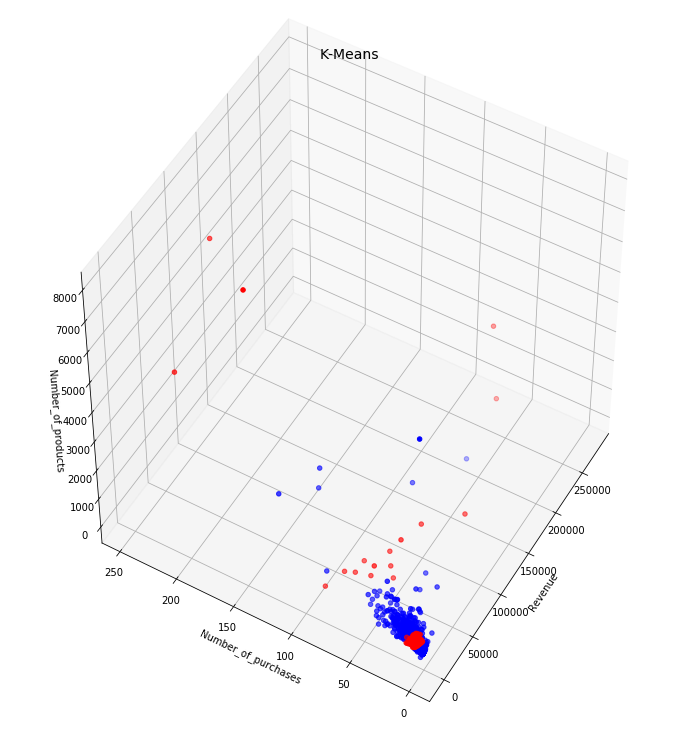

```python
plot_normal_vs_anomalous(customer_analytics,'anomaly_kmeans', 'K-Means' )
```

**DBSCAN**

DBSCAN stands for Density-based spatial clustering of applications with noise. It practically identifies clusters of dense regions, while simultaneously labeling noisy instances (those that are in a sparse area, and cannot be joined to any cluster).

Find out more at: https://towardsdatascience.com/how-dbscan-works-and-why-should-i-use-it-443b4a191c80

**Pros**: Good for highly densed data, when the preassumption of isolated points in sparse areas is satisfied.

**Cons**: Not good when dealing with collective anomalies, since it can labes cluster of collective anomaly as normal, while it's not. Although, this can be managed in the post-processing phase.

```python
from sklearn.cluster import DBSCAN
```

```python
data = MinMaxScaler(feature_range=(0,1)).fit_transform(customer_analytics[features_to_use])
dbscan_model = DBSCAN(eps=0.2, min_samples=2)
dbscan_model.fit(data)
```

```
DBSCAN(algorithm='auto', eps=0.2, leaf_size=30, metric='euclidean',
    metric_params=None, min_samples=2, n_jobs=1, p=None)
```

```python
customer_analytics['Anomaly_dbscan'] = dbscan_model.labels_
```

```python
customer_analytics['Anomaly_dbscan'].value_counts()
```

```
 0    4362
-1       7
 1       3
Name: Anomaly_dbscan, dtype: int64
```

```python
customer_analytics.groupby('Anomaly_dbscan')[features_to_use].describe().T
```

|  | Anomaly_dbscan | -1 | 0 | 1 |
| --- | --- | --- | --- | --- |
| Revenue | count | 7.000000 | 4362.000000 | 3.000000 |
|  | mean | 140359.441429 | 1648.104231 | 42839.690000 |
|  | std | 103625.792637 | 4540.506342 | 26974.936083 |
|  | min | 29072.100000 | -4287.630000 | 11713.850000 |
|  | 25% | 48730.845000 | 292.532500 | 34549.865000 |
|  | 50% | 132572.620000 | 646.130000 | 57385.880000 |
|  | 75% | 221960.330000 | 1603.655000 | 58402.610000 |
|  | max | 279489.020000 | 123725.450000 | 59419.340000 |
| Number_of_purchases | count | 7.000000 | 4362.000000 | 3.000000 |
|  | mean | 124.142857 | 4.804448 | 121.333333 |
|  | std | 87.858653 | 6.682023 | 5.773503 |
|  | min | 34.000000 | 1.000000 | 118.000000 |
|  | 25% | 58.500000 | 1.000000 | 118.000000 |
|  | 50% | 77.000000 | 3.000000 | 118.000000 |
|  | 75% | 196.500000 | 5.000000 | 123.000000 |
|  | max | 248.000000 | 89.000000 | 128.000000 |
| Number_of_products | count | 7.000000 | 4362.000000 | 3.000000 |
|  | mean | 3789.285714 | 85.551123 | 2376.666667 |
|  | std | 2903.025934 | 129.985335 | 472.980267 |
|  | min | 351.000000 | 1.000000 | 1857.000000 |
|  | 25% | 1259.000000 | 17.000000 | 2174.000000 |
|  | 50% | 4642.000000 | 42.000000 | 2491.000000 |
|  | 75% | 5515.500000 | 101.000000 | 2636.500000 |
|  | max | 7983.000000 | 1677.000000 | 2782.000000 |

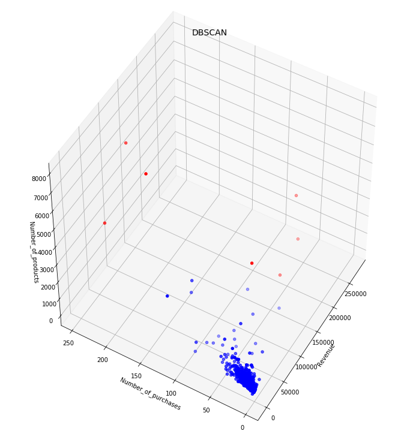

```python
plot_normal_vs_anomalous(customer_analytics,'Anomaly_dbscan', 'DBSCAN')
```

If you'd like more of this, check this out:

- https://towardsdatascience.com/how-dbscan-works-and-why-should-i-use-it-443b4a191c80
- https://medium.com/datadriveninvestor/how-to-clustering-and-detect-outlier-at-the-same-time-30576acd75d0

### Ensemble based anomaly detection

**Isolation Forest**

The Isolation Forest is an ensemble-based method. And if you’re familiar with how the Random Forest works (I know you are, we all love it!), there is no doubt that you’ll quickly master the Isolation Forest algorithm.

One thing that should be clarified prior to the algorithm explanation is the concept of the “instance isolation”. While most of other algorithms are trying to model the normal behaviour, to learn the profile patterns, this algorithm tries to separate the anomalous instance from the rest of the data (thus the term “isolation”). The easier it is to isolate the instance, the higher the chances are it is anomalous.

So, basically, Isolation Forest (iForest) works by building an ensemble of trees, called Isolation trees (iTrees), for a given dataset. A particular iTree is built upon a feature, by performing the partitioning. If we have a feature with a given data range, the first step of the algorithm is to randomly select a split value out of the available range of values. When the split value is chosen, the partitioning starts – each instance with a feature value lower than the split value is routed in the one side of the tree, while each instance with a feature value higher or equal than the split value is routed in the opposite side of the tree. In the second step, another random split value is selected, out of the available range of values for each side of the tree. This is recursively done until all instances are placed into terminal nodes (leaves), or some of the criteria set in the input parameters is met.

The idea is simple – if the instance is easily isolated (meaning there were fewer steps taken in order to place it into a terminal node), it has higher chances to be an anomaly.

I have dedicated a blog post to this algorithm: https://thingsolver.com/friday-talks-the-dark-horse-of-isolation-forest/. The original paper and further materials are linked within.

**Pros**: Extreemy fast and efficient, even with the high dimensional data. Having mechanisms for solving swamping and masking problem efficienty.

**Cons**: Not being able to return variable-based anomaly score. Not able to analyse contextual variables like time and space.

```python
features_to_use
```

```
['Revenue', 'Number_of_purchases', 'Number_of_products']
```

```python
# define a model
from sklearn.ensemble import IsolationForest
```

```python
model = IsolationForest(n_estimators=100,
                        max_samples=256,
                        max_features=len(features_to_use),
                        contamination=0.05)
```

```python
# fit the model
model.fit(customer_analytics[features_to_use])
```

```
IsolationForest(bootstrap=False, contamination=0.05, max_features=3,
        max_samples=256, n_estimators=100, n_jobs=1, random_state=None,
        verbose=0)
```

```python
labels = model.predict(customer_analytics[features_to_use])
```

```python
customer_analytics['Anomaly_IF'] = labels
```

```python
customer_analytics['Anomaly_IF'].value_counts()
```

```
 1    4153
-1     219
Name: Anomaly_IF, dtype: int64
```

```python
customer_analytics.describe()
```

|  | CustomerID | Revenue | Number_of_purchases | Number_of_products | anomaly_kmeans | Anomaly_dbscan | Anomaly_IF |
| --- | --- | --- | --- | --- | --- | --- | --- |
| count | 4372.000000 | 4372.000000 | 4372.000000 | 4372.000000 | 437.0 | 4372.000000 | 4372.000000 |
| mean | 15299.677722 | 1898.459701 | 5.075480 | 93.053294 | -1.0 | -0.000915 | 0.899817 |
| std | 1722.390705 | 8219.345141 | 9.338754 | 232.471608 | 0.0 | 0.047822 | 0.436317 |
| min | 12346.000000 | -4287.630000 | 1.000000 | 1.000000 | -1.0 | -1.000000 | -1.000000 |
| 25% | 13812.750000 | 293.362500 | 1.000000 | 17.000000 | -1.0 | 0.000000 | 1.000000 |
| 50% | 15300.500000 | 648.075000 | 3.000000 | 42.000000 | -1.0 | 0.000000 | 1.000000 |
| 75% | 16778.250000 | 1611.725000 | 5.000000 | 102.000000 | -1.0 | 0.000000 | 1.000000 |
| max | 18287.000000 | 279489.020000 | 248.000000 | 7983.000000 | -1.0 | 1.000000 | 1.000000 |

```python
customer_analytics.groupby('Anomaly_IF')[features_to_use].describe().T
```

|  | Anomaly_IF | -1 | 1 |
| --- | --- | --- | --- |
| Revenue | count | 219.000000 | 4153.000000 |
|  | mean | 17720.406073 | 1064.121571 |
|  | std | 32562.559661 | 1244.493365 |
|  | min | 1296.440000 | -4287.630000 |
|  | 25% | 5647.950000 | 277.410000 |
|  | 50% | 8933.520000 | 605.580000 |
|  | 75% | 14577.360000 | 1377.920000 |
|  | max | 279489.020000 | 10217.480000 |
| Number_of_purchases | count | 219.000000 | 4153.000000 |
|  | mean | 30.050228 | 3.758488 |
|  | std | 29.073179 | 3.577479 |
|  | min | 3.000000 | 1.000000 |
|  | 25% | 16.000000 | 1.000000 |
|  | 50% | 23.000000 | 2.000000 |
|  | 75% | 32.500000 | 5.000000 |
|  | max | 248.000000 | 24.000000 |
| Number_of_products | count | 219.000000 | 4153.000000 |
|  | mean | 588.369863 | 66.933783 |
|  | std | 843.691569 | 76.791332 |
|  | min | 9.000000 | 1.000000 |
|  | 25% | 261.000000 | 16.000000 |
|  | 50% | 424.000000 | 38.000000 |
|  | 75% | 604.500000 | 89.000000 |
|  | max | 7983.000000 | 547.000000 |

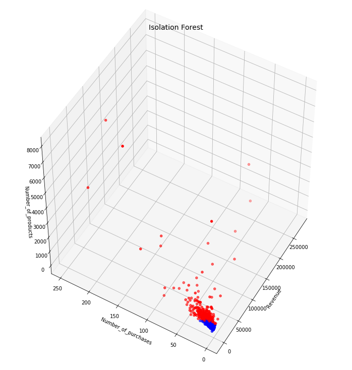

```python
plot_normal_vs_anomalous(customer_analytics,'Anomaly_IF', 'Isolation Forest')
```

### Gaussian distribution-based anomaly detection

**Elliptic Envelope**

Elliptic envelope is a robust co-variance estimate that assumes that the data is Gaussian distributed. It will define the shape of the data, creating a frontier that delimits the contour. The frontier will be elliptical in shape, and everything lying outside the frontier is regarded as anomalous.

**Pros**: Efficient and able to work with multivariate data. Gives a possibility to choose the fraction of anomalies within the dataset.

**Cons**: Due to its nature, in does not work well when there is no elliptic boundary between normal and anomalous instances.

```python
# define a model
from sklearn.covariance import EllipticEnvelope
```

```python
model_ee = EllipticEnvelope(contamination=0.05)
# fit the model
model_ee.fit(customer_analytics[features_to_use])
labels = model_ee.predict(customer_analytics[features_to_use])
customer_analytics['Anomaly_EE'] = labels
```

```python
customer_analytics.groupby('Anomaly_EE')[features_to_use].describe().T
```

|  | Anomaly_EE | -1 | 1 |
| --- | --- | --- | --- |
| Revenue | count | 219.000000 | 4153.000000 |
|  | mean | 17691.022192 | 1065.671070 |
|  | std | 32584.230757 | 1235.402606 |
|  | min | 1093.650000 | -4287.630000 |
|  | 25% | 5809.625000 | 277.410000 |
|  | 50% | 9065.760000 | 605.580000 |
|  | 75% | 14577.360000 | 1382.020000 |
|  | max | 279489.020000 | 8221.090000 |
| Number_of_purchases | count | 219.000000 | 4153.000000 |
|  | mean | 28.141553 | 3.859138 |
|  | std | 29.994083 | 3.877352 |
|  | min | 1.000000 | 1.000000 |
|  | 25% | 12.000000 | 1.000000 |
|  | 50% | 22.000000 | 2.000000 |
|  | 75% | 32.500000 | 5.000000 |
|  | max | 248.000000 | 29.000000 |
| Number_of_products | count | 219.000000 | 4153.000000 |
|  | mean | 570.853881 | 67.857452 |
|  | std | 852.316389 | 77.944504 |
|  | min | 4.000000 | 1.000000 |
|  | 25% | 198.500000 | 16.000000 |
|  | 50% | 433.000000 | 38.000000 |
|  | 75% | 604.500000 | 90.000000 |
|  | max | 7983.000000 | 472.000000 |

```python
customer_analytics[customer_analytics['Anomaly_IF']!=customer_analytics['Anomaly_EE']]
```

|  | CustomerID | Revenue | Number_of_purchases | Number_of_products | anomaly_kmeans | Anomaly_dbscan | Anomaly_IF | Anomaly_EE |
| --- | --- | --- | --- | --- | --- | --- | --- | --- |
| 10 | 12357.0 | 6207.67 | 1 | 131 | NaN | 0 | 1 | -1 |
| 73 | 12435.0 | 7829.89 | 2 | 36 | NaN | 0 | 1 | -1 |
| 278 | 12683.0 | 8221.09 | 20 | 362 | NaN | 0 | -1 | 1 |
| 308 | 12720.0 | 5713.28 | 29 | 359 | NaN | 0 | -1 | 1 |
| 328 | 12744.0 | 9120.39 | 10 | 229 | NaN | 0 | 1 | -1 |
| 365 | 12798.0 | 6977.04 | 3 | 8 | NaN | 0 | 1 | -1 |
| 385 | 12830.0 | 6748.40 | 7 | 39 | NaN | 0 | 1 | -1 |
| 491 | 12980.0 | 7092.06 | 12 | 24 | NaN | 0 | 1 | -1 |
| 510 | 13004.0 | 5613.43 | 22 | 409 | NaN | 0 | -1 | 1 |
| 525 | 13027.0 | 6912.00 | 6 | 26 | NaN | 0 | 1 | -1 |
| 543 | 13050.0 | 5684.61 | 28 | 422 | NaN | 0 | -1 | 1 |
| 572 | 13093.0 | 7741.47 | 13 | 170 | NaN | 0 | 1 | -1 |
| 579 | 13102.0 | 6336.29 | 27 | 310 | NaN | 0 | -1 | 1 |
| 669 | 13225.0 | 6083.04 | 8 | 34 | NaN | 0 | 1 | -1 |
| 701 | 13267.0 | 4404.44 | 27 | 224 | NaN | 0 | -1 | 1 |
| 745 | 13324.0 | 7072.80 | 12 | 77 | NaN | 0 | 1 | -1 |
| 809 | 13418.0 | 5845.44 | 23 | 314 | NaN | 0 | -1 | 1 |
| 889 | 13521.0 | 1093.65 | 3 | 436 | NaN | 0 | 1 | -1 |
| 959 | 13629.0 | 7792.36 | 11 | 59 | NaN | 0 | 1 | -1 |
| 1293 | 14085.0 | 4435.79 | 19 | 451 | NaN | 0 | -1 | 1 |
| 1304 | 14101.0 | 5976.79 | 6 | 35 | NaN | 0 | 1 | -1 |
| 1645 | 14562.0 | 4709.22 | 22 | 446 | NaN | 0 | -1 | 1 |
| 1731 | 14684.0 | 1236.28 | 5 | 421 | NaN | 0 | 1 | -1 |
| 1733 | 14688.0 | 5107.38 | 27 | 359 | NaN | 0 | -1 | 1 |
| 1846 | 14849.0 | 7904.28 | 28 | 392 | NaN | 0 | -1 | 1 |
| 1911 | 14936.0 | 8117.42 | 9 | 366 | NaN | 0 | 1 | -1 |
| 1919 | 14952.0 | 7912.79 | 15 | 149 | NaN | 0 | 1 | -1 |
| 1984 | 15044.0 | 7629.38 | 22 | 461 | NaN | 0 | -1 | 1 |
| 2102 | 15194.0 | 7521.17 | 22 | 326 | NaN | 0 | -1 | 1 |
| 2408 | 15601.0 | 6745.36 | 17 | 414 | NaN | 0 | -1 | 1 |
| 2613 | 15867.0 | 3797.79 | 16 | 463 | NaN | 0 | -1 | 1 |
| 2794 | 16126.0 | 6287.77 | 4 | 117 | NaN | 0 | 1 | -1 |
| 2825 | 16168.0 | 3770.60 | 28 | 99 | NaN | 0 | -1 | 1 |
| 2836 | 16180.0 | 10217.48 | 10 | 176 | NaN | 0 | 1 | -1 |
| 2838 | 16182.0 | 6617.65 | 4 | 28 | NaN | 0 | 1 | -1 |
| 2847 | 16191.0 | 4913.32 | 25 | 151 | NaN | 0 | -1 | 1 |
| 3096 | 16532.0 | 6748.80 | 3 | 4 | NaN | 0 | 1 | -1 |
| 3249 | 16746.0 | 6694.31 | 19 | 452 | NaN | 0 | -1 | 1 |
| 3305 | 16813.0 | 1692.98 | 10 | 449 | NaN | 0 | 1 | -1 |
| 3306 | 16814.0 | 6500.60 | 22 | 325 | NaN | 0 | -1 | 1 |
| 3427 | 16984.0 | 4392.42 | 5 | 418 | NaN | 0 | -1 | 1 |
| 3590 | 17220.0 | 3198.25 | 14 | 472 | NaN | 0 | -1 | 1 |
| 3692 | 17365.0 | 4801.56 | 8 | 468 | NaN | 0 | -1 | 1 |
| 3702 | 17377.0 | 3925.92 | 21 | 419 | NaN | 0 | -1 | 1 |
| 3716 | 17396.0 | 7330.80 | 8 | 27 | NaN | 0 | 1 | -1 |
| 3850 | 17576.0 | 3457.78 | 22 | 417 | NaN | 0 | -1 | 1 |
| 4208 | 18069.0 | 2021.82 | 7 | 472 | NaN | 0 | 1 | -1 |
| 4225 | 18092.0 | 9065.76 | 12 | 90 | NaN | 0 | 1 | -1 |
| 4260 | 18139.0 | 8393.22 | 8 | 162 | NaN | 0 | 1 | -1 |
| 4324 | 18223.0 | 6315.23 | 27 | 299 | NaN | 0 | -1 | 1 |

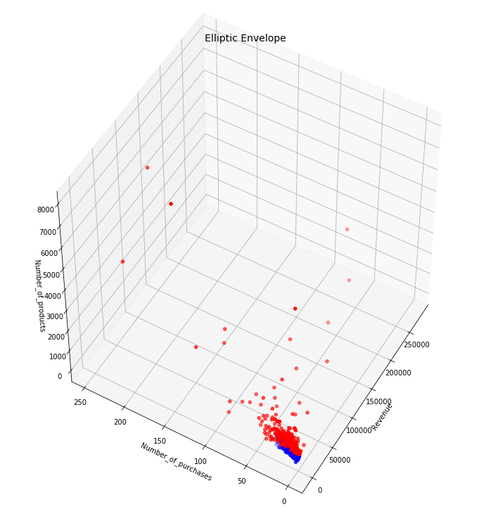

```python
plot_normal_vs_anomalous(customer_analytics,'Anomaly_EE', 'Elliptic Envelope')
```

### Kernel based anomaly detection

**OneClass SVM**

This is one of the max-margin methods, which does not model the distribution. It tries to build maximum margin - a maximum distances between data points of different classed. This algorithm is a modification of the classic SVM algorithm, in terms that it models only one class.

**Pros**: Most convenient for novelty detection, detecting behaviour not seen before.

**Cons**: Not suitable for large, high-dimensional datasets, since it can be pretty resource-consuiming and extreemly slow.

```python
from sklearn.svm import OneClassSVM
```

```python
model_ocsvm = OneClassSVM(kernel='sigmoid', gamma='auto')
# fit the model
model_ocsvm.fit(customer_analytics[features_to_use])
labels = model_ocsvm.predict(customer_analytics[features_to_use])
customer_analytics['Anomaly_OCSVM'] = labels
```

```python
np.round(customer_analytics.groupby('Anomaly_OCSVM')[features_to_use].describe().T)
```

|  | Anomaly_OCSVM | -1 | 1 |
| --- | --- | --- | --- |
| Revenue | count | 4334.0 | 38.0 |
|  | mean | 1915.0 | 17.0 |
|  | std | 8253.0 | 16.0 |
|  | min | -4288.0 | -0.0 |
|  | 25% | 301.0 | 0.0 |
|  | 50% | 656.0 | 15.0 |
|  | 75% | 1624.0 | 34.0 |
|  | max | 279489.0 | 39.0 |
| Number_of_purchases | count | 4334.0 | 38.0 |
|  | mean | 5.0 | 2.0 |
|  | std | 9.0 | 1.0 |
|  | min | 1.0 | 1.0 |
|  | 25% | 1.0 | 1.0 |
|  | 50% | 3.0 | 1.0 |
|  | 75% | 6.0 | 2.0 |
|  | max | 248.0 | 4.0 |
| Number_of_products | count | 4334.0 | 38.0 |
|  | mean | 94.0 | 12.0 |
|  | std | 233.0 | 33.0 |
|  | min | 1.0 | 1.0 |
|  | 25% | 18.0 | 1.0 |
|  | 50% | 42.0 | 2.0 |
|  | 75% | 102.0 | 10.0 |
|  | max | 7983.0 | 202.0 |

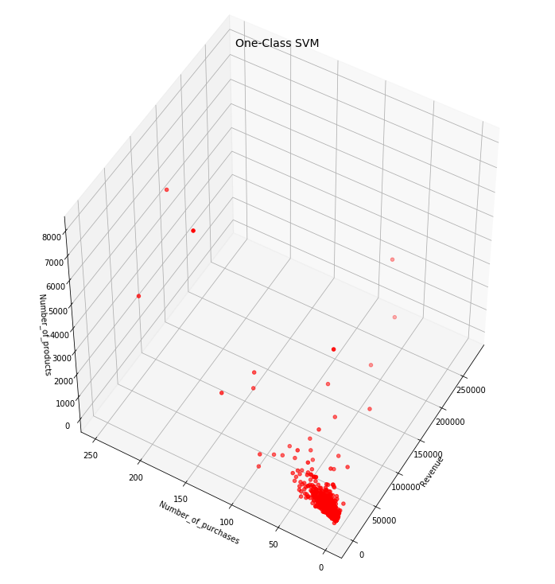

```python
plot_normal_vs_anomalous(customer_analytics,'Anomaly_OCSVM', 'One-Class SVM')
```

Check this blog post to find more interesting examples and comparisons:

- https://towardsdatascience.com/detecting-the-onset-of-machine-failure-using-anomaly-detection-techniques-d2f7a11eb809

### Representation-based anomaly detection

**Autoencoder**

Autoencoder is a unsupervised neural network. In most cases, the main goal of training an autoencoder is to provide an output that is the same as input.

They work by compressing the input into a latent-space representation, and then reconstructing the output from this representation. It is consisted of two parts: encoder and decoder.

Encoder is used for mapping from the original space to another space, of possibly higher or lower dimensionality.

Decoder is used for mapping back from this new space to the original one.

Anomaly score is determined by the error a decoder made in reconstruction phase.

This example was inspired by this blog post: https://edouardfouche.com/Neural-based-Outlier-Discovery/.

**Pros**: Convenient for high-dimensional datasets. Able to return anomaly score for each variable.

**Cons**: May be extreemly resource consuming in some cases (if the architecture is complex, with lots of hyperparameters).

```python
from sklearn.preprocessing import MinMaxScaler, StandardScaler
```

```python
# scaler = MinMaxScaler(feature_range=(0,1))
scaler = StandardScaler()
X_train = scaler.fit_transform(customer_analytics[features_to_use].values)
```

```python
import numpy as np
from keras.layers import Input, Dense
from keras.models import Model
from keras.datasets import mnist
import matplotlib.pyplot as plt

# this is the size of our encoded representations
encoding_dim = 1

# this is our input placeholder
input_shape = Input(shape=(3,))
# "encoded" is the encoded representation of the input
encoded = Dense(encoding_dim, activation='relu')(input_shape)
# "decoded" is the lossy reconstruction of the input
decoded = Dense(3, activation='sigmoid')(encoded) # try changing to relu
# this model maps an input to its reconstruction
autoencoder = Model(input_shape, decoded)
# this model maps an input to its encoded representation
encoder = Model(input_shape, encoded)
# create a placeholder for an encoded (32-dimensional) input
encoded_input = Input(shape=(encoding_dim,))
# retrieve the last layer of the autoencoder model
decoder_layer = autoencoder.layers[-1]
# create the decoder model
decoder = Model(encoded_input, decoder_layer(encoded_input))
# # configure our model to use a per-pixel binary crossentropy loss, and the Adadelta optimizer:
autoencoder.compile(optimizer='adadelta', loss='binary_crossentropy')
```

```python
autoencoder.predict(X_train)
```

```
array([[0.5       , 0.5       , 0.5       ],
       [0.44875938, 0.51572955, 0.5383378 ],
       [0.5       , 0.5       , 0.5       ],
       ...,
       [0.5       , 0.5       , 0.5       ],
       [0.20819879, 0.60078967, 0.7306452 ],
       [0.4989537 , 0.50032014, 0.5007816 ]], dtype=float32)
```

```python
encoded = encoder.predict(X_train)
decoded = decoder.predict(encoded)
```

```python
import numpy as np
dist = np.zeros(len(X_train))
for i, x in enumerate(X_train):
#     dist[i] = np.linalg.norm(x-decoded[i])
    dist[i] = abs(np.sum(x-decoded[i]))
```

```python
dist
```

```
array([2.45208284, 0.6206357 , 1.89445156, ..., 2.27617855, 2.50626317,
       1.8289463 ])
```

```python
# score represents this distance. The higher it is, the higher the probability that the instance is anomaly
customer_analytics['Anomaly_AE']=dist
```

```python
print(customer_analytics.Anomaly_AE.min())
print(customer_analytics.Anomaly_AE.max())
```

```
0.00429083836149291
64.96449132277169
```

```python
anomalous_customer = customer_analytics[customer_analytics.Anomaly_AE==customer_analytics.Anomaly_AE.max()]
```

```python
anomalous_customer
```

[output not shown]

```python
anomalous_customers = customer_analytics.sort_values(by='Anomaly_AE', ascending=False).head(100)
```

```python
# anomalous customers
anomalous_customers[features_to_use].describe()
```

|  | Revenue | Number_of_purchases | Number_of_products |
| --- | --- | --- | --- |
| count | 100.000000 | 100.000000 | 100.0000 |
| mean | 29647.905500 | 44.230000 | 855.8800 |
| std | 45276.256653 | 37.717144 | 1178.9845 |
| min | -4287.630000 | 1.000000 | 1.0000 |
| 25% | 8074.630000 | 26.750000 | 336.7500 |
| 50% | 13644.830000 | 33.500000 | 503.5000 |
| 75% | 30550.635000 | 49.250000 | 928.2500 |
| max | 279489.020000 | 248.000000 | 7983.0000 |

```python
# non-anomalous customers
customer_analytics[~(customer_analytics.index.isin(anomalous_customers.index))][features_to_use].describe()
```

|  | Revenue | Number_of_purchases | Number_of_products |
| --- | --- | --- | --- |
| count | 4272.000000 | 4272.000000 | 4272.000000 |
| mean | 1248.894022 | 4.158942 | 75.196863 |
| std | 1780.821855 | 4.420877 | 95.630515 |
| min | -1592.490000 | 1.000000 | 1.000000 |
| 25% | 288.360000 | 1.000000 | 17.000000 |
| 50% | 628.580000 | 3.000000 | 40.000000 |
| 75% | 1497.137500 | 5.000000 | 96.000000 |
| max | 21535.900000 | 39.000000 | 803.000000 |

```python
customer_analytics['Anomaly_AE_flag'] = 1
customer_analytics['Anomaly_AE_flag'][(customer_analytics.index.isin(anomalous_customers.index))] = -1
```

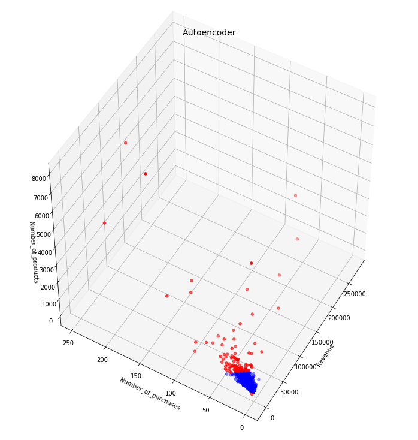

```python
plot_normal_vs_anomalous(customer_analytics,'Anomaly_AE_flag', 'Autoencoder');
```

If you're hungry for more of this, I encourage you to investigate variations of Autoencoder for the problem of anomaly detection:

- LSTM Autoencoder:
  - https://machinelearningmastery.com/lstm-autoencoders
  - https://towardsdatascience.com/lstm-autoencoder-for-extreme-rare-event-classification-in-keras-ce209a224cfb
  - https://arxiv.org/pdf/1607.00148.pdf
- Variational Autoencoder:
  - https://arxiv.org/abs/1907.01702
  - https://www.semanticscholar.org/paper/Variational-Autoencoder-based-Anomaly-Detection-An-Cho/061146b1d7938d7a8dae70e3531a00fceb3c78e8
  - https://pdfs.semanticscholar.org/82c0/1c949a5106feef6eeec1b7e6a5e29508495f.pdf

# Thanks!

Additional materials:

- https://github.com/yzhao062/pyod
- http://cucis.ece.northwestern.edu/projects/DMS/publications/AnomalyDetection.pdf
- https://pdfs.semanticscholar.org/0c70/0847fa371cfe9b28f30eacf57fcd4243998e.pdf
- https://pdfs.semanticscholar.org/f8f4/fc696d80f9c89bb59d30080d961ddf242b68.pdf
- http://blog.easysol.net/using-isolation-forests-anamoly-detection/
- https://indico.cern.ch/event/393368/
- http://citeseerx.ist.psu.edu/viewdoc/download?doi=10.1.1.88.4485&rep=rep1&type=pdf